# simon-5502-08-demo

# Start part 1 —————————————————————-

## File details

This program was written by Steve Simon on 2025-02-23 and is placed in the public domain. You can use this program any way you please.

This is the correct program for the Spring 2026 semester.

There is one data file used in this program

- whas500, [Tab delimited file](https://github.com/pmean/data/blob/main/files/whas500.dat), [dictionary](https://github.com/pmean/data/blob/main/files/whas500.yaml)

```r
library(broom)
library(ggfortify)
library(glue)
library(lubridate)
library(survival)
library(tidyverse)

R.version.string
```

```
[1] "R version 4.5.0 (2025-04-11 ucrt)"
```

```r
Sys.Date()
```

```
[1] "2026-03-10"
```

## Read Worcester Heart Attack Study

```r
whas_names <- c(
  "id",
  "age",
  "gender",
  "hr",
  "sysbp",
  "diasbp",
  "bmi",
  "cvd",
  "afb",
  "sho",
  "chf",
  "av3",
  "miord",
  "mitype",
  "year",
  "admitdate",
  "disdate",
  "fdate",
  "los",
  "dstat",
  "lenfol",
  "fstat",
  "not_needed")

whas0 <- read_table(
  file="../data/whas500.dat",
  col_types="nnnnnnnnnnnnnnncccnnnnn",
  col_names=whas_names)

glimpse(whas0)
```

```
Rows: 500
Columns: 23
$ id         <dbl> 1, 2, 3, 4, 5, 6, 7, 8, 9, 10, 11, 12, 13, 14, 15, 16, 17, …
$ age        <dbl> 83, 49, 70, 70, 70, 70, 57, 55, 88, 54, 48, 75, 48, 54, 67,…
$ gender     <dbl> 0, 0, 1, 0, 0, 0, 0, 0, 1, 0, 0, 0, 0, 1, 0, 0, 1, 1, 0, 0,…
$ hr         <dbl> 89, 84, 83, 65, 63, 76, 73, 91, 63, 104, 95, 154, 85, 95, 9…
$ sysbp      <dbl> 152, 120, 147, 123, 135, 83, 191, 147, 209, 166, 160, 193, …
$ diasbp     <dbl> 78, 60, 88, 76, 85, 54, 116, 95, 100, 106, 110, 123, 80, 65…
$ bmi        <dbl> 25.54051, 24.02398, 22.14290, 26.63187, 24.41255, 23.24236,…
$ cvd        <dbl> 1, 1, 0, 1, 1, 1, 1, 1, 1, 1, 0, 1, 1, 1, 0, 0, 1, 0, 0, 1,…
$ afb        <dbl> 1, 0, 0, 0, 0, 0, 0, 0, 0, 0, 0, 1, 0, 1, 0, 0, 0, 0, 0, 0,…
$ sho        <dbl> 0, 0, 0, 0, 0, 0, 0, 0, 0, 0, 0, 0, 0, 0, 0, 0, 0, 0, 0, 0,…
$ chf        <dbl> 0, 0, 0, 1, 0, 0, 0, 0, 1, 0, 0, 1, 0, 1, 0, 0, 1, 1, 0, 1,…
$ av3        <dbl> 0, 0, 0, 0, 0, 1, 0, 0, 0, 0, 0, 0, 0, 0, 0, 0, 0, 0, 0, 1,…
$ miord      <dbl> 1, 0, 0, 0, 0, 0, 0, 0, 0, 0, 0, 0, 0, 0, 1, 1, 1, 0, 0, 0,…
$ mitype     <dbl> 0, 1, 1, 1, 1, 0, 1, 1, 0, 0, 1, 1, 0, 0, 0, 0, 0, 1, 1, 1,…
$ year       <dbl> 1, 1, 1, 1, 1, 1, 1, 1, 1, 1, 1, 1, 1, 1, 1, 1, 1, 1, 1, 1,…
$ admitdate  <chr> "01/13/1997", "01/19/1997", "01/01/1997", "02/17/1997", "03…
$ disdate    <chr> "01/18/1997", "01/24/1997", "01/06/1997", "02/27/1997", "03…
$ fdate      <chr> "12/31/2002", "12/31/2002", "12/31/2002", "12/11/1997", "12…
$ los        <dbl> 5, 5, 5, 10, 6, 1, 5, 4, 4, 5, 5, 10, 7, 21, 4, 1, 13, 14, …
$ dstat      <dbl> 0, 0, 0, 0, 0, 1, 0, 0, 0, 0, 0, 0, 0, 0, 0, 0, 0, 0, 0, 0,…
$ lenfol     <dbl> 2178, 2172, 2190, 297, 2131, 1, 2122, 1496, 920, 2175, 2173…
$ fstat      <dbl> 0, 0, 0, 1, 0, 1, 0, 1, 1, 0, 0, 1, 0, 1, 0, 0, 1, 1, 0, 1,…
$ not_needed <dbl> NA, NA, NA, NA, NA, NA, NA, NA, NA, NA, NA, NA, NA, NA, NA,…
```

## Convert dates, add factors

```r
whas0 |>
  select(-not_needed) |>
  mutate(lenfol=lenfol/365.25) -> whas1
```

#### Comments on the code

For long term studies, you will find it easier to interpret results if the follow-up time is measured in years rather than days. The 365.25 in the divisor accounts for leap years. It is not a perfect adjustment, especially for follow-up times less than four years, but it comes close enough.

## Count events

```r
whas1 |>
  count(fstat) |>
  mutate(total=sum(n)) |>
  mutate(pct=round(100*n/total)) |>
  mutate(pct=glue("{pct}% ({n}/{total})")) |>
  select(-n, -total) -> whas_fstat_count_table

whas_fstat_count_table
```

```
# A tibble: 2 × 2
  fstat pct
  <dbl> <glue>
1     0 57% (285/500)
2     1 43% (215/500)
```

#### Interpretation of the output

There are enough events to support a reasonably complex model (215/15 = 14.3).

## Overall Kaplan-Meier curve

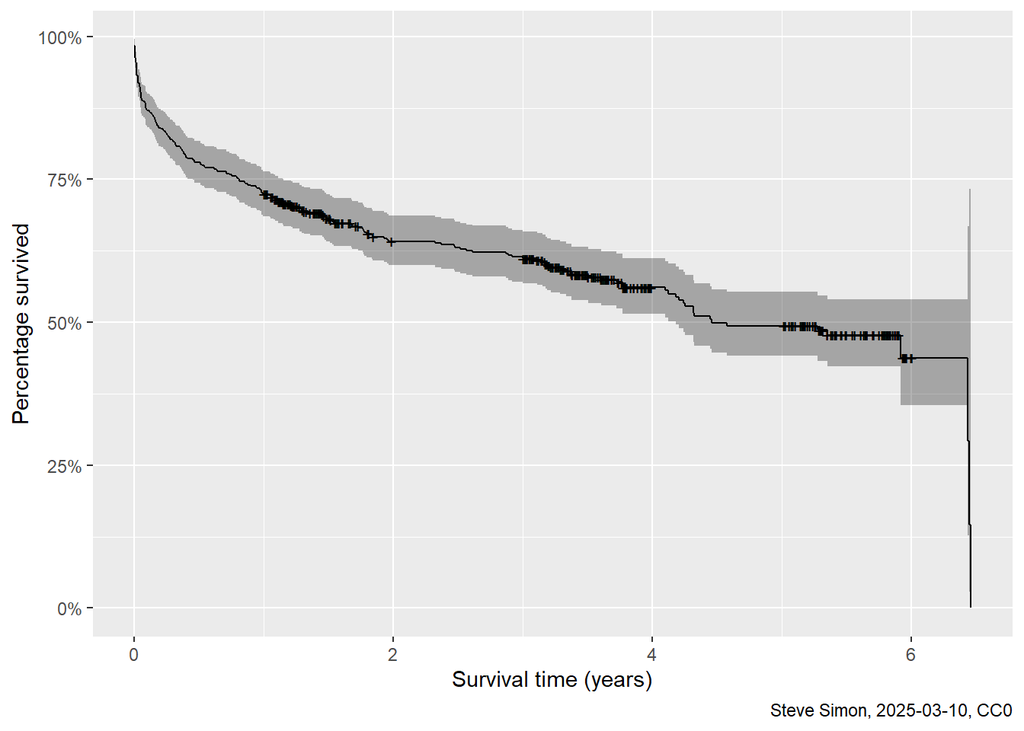

```r
whas_null_km_model <- survfit(
  formula=Surv(lenfol, fstat) ~ 1,
  data=whas1)

autoplot(whas_null_km_model, conf.int=TRUE) +
  labs(
    x="Survival time (years)",
    y="Percentage survived",
    caption="Steve Simon, 2025-03-10, CC0") -> whas_null_km_plot

whas_null_km_plot
```

#### Comments on the code

The [Surv function](https://stat.ethz.ch/R-manual/R-devel/library/survival/html/Surv.html), part of the survival package, creates a survival object that combines information about the follow-up time combined with a censoring variable. The [survfit function](https://stat.ethz.ch/R-manual/R-devel/library/survival/html/survfit.html) creates a Kaplan-Meier curve.

The conf.int argument tells R whether to place confidence limits on the survival curve. I generally don’t do this because it can clutter up the graph, but other researchers like it. I will use confidence limits if there is only one survival curve.

#### Interpretation of the output

The survival probabilities decline over time, a bit more sharply in the first year than in later years. The censored observations (the plus signs on the graphs) are clustered. An investigation into this would yield a reasonable explanation, but I will leave this unsaid for now.

## Start part 2 —————————————————————-

## Descriptive statistics on gender

```r
whas1 |>
    count(gender, fstat) -> whas_gender_count_table

whas_gender_count_table
```

```
# A tibble: 4 × 3
  gender fstat     n
   <dbl> <dbl> <int>
1      0     0   189
2      0     1   111
3      1     0    96
4      1     1   104
```

#### Comments on the code

Although I normally compute percentages after using the count function, it is not needed here. I just want to make sure that the number of events is reasonably large in both groups.

#### Interpretation of the output

There are a reasonable number of events (fstat=1) among both males (111) and females (104).

## Comparison of two or more survival curves

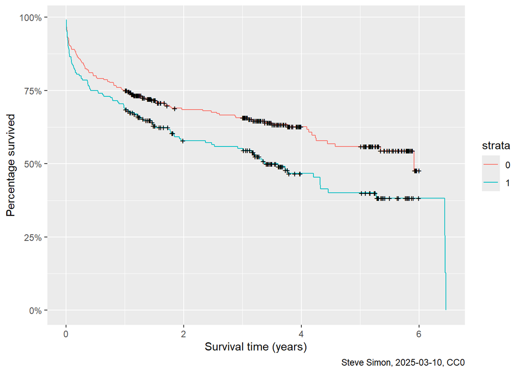

```r
whas_gender_km_model <- survfit(
  formula=Surv(lenfol, fstat) ~ gender,
  data=whas1)

autoplot(whas_gender_km_model, conf.int=FALSE) +
  labs(
    x="Survival time (years)",
    y="Percentage survived",
    caption="Steve Simon, 2025-03-10, CC0") -> whas_gender_km_plot

whas_gender_km_plot
```

#### Comments on the code

The survift function, described above, allows you to draw seperate curves for any categorical variable. Place that categorical variable on the right hand side of the tilde. With two curves, I decided to suppress the confidence limits with the argument conf.int=FALSE.

#### Interpretation of the output

The females (gender=1) have a slightly worse outcome than males because their curve is closer to the sad lower left corner of the graph. At two years, the survival probability is about 10% lower.

## Log rank test

```r
survdiff(
  formula=Surv(lenfol, fstat) ~ gender,
  data=whas1) -> whas_gender_logrank_model

whas_gender_logrank_model
```

```
Call:
survdiff(formula = Surv(lenfol, fstat) ~ gender, data = whas1)

           N Observed Expected (O-E)^2/E (O-E)^2/V
gender=0 300      111    130.7      2.98      7.79
gender=1 200      104     84.3      4.62      7.79

 Chisq= 7.8  on 1 degrees of freedom, p= 0.005
```

#### Comments on the code

The [survdiff function](https://stat.ethz.ch/R-manual/R-devel/library/survival/html/survdiff.html) takes a formula for a survival model and runs a logrank test. Other tests are also available for this function.

#### Interpretation of the output

Males (gender=0) have fewer deaths than you would expect under the null hypothesis while females (gender=1) have more deaths than expected. This difference is statistically significant because the chi-squared statistic is much larger than its degrees of freedom and the p-value is small.

## Cox model for gender

```r
coxph(
  formula=Surv(lenfol, fstat) ~ gender,
  data=whas1) -> whas_gender_cox_model

whas_gender_cox_model
```

```
Call:
coxph(formula = Surv(lenfol, fstat) ~ gender, data = whas1)

         coef exp(coef) se(coef)     z       p
gender 0.3815    1.4645   0.1376 2.773 0.00556

Likelihood ratio test=7.6  on 1 df, p=0.005843
n= 500, number of events= 215
```

## Start part 3 —————————————————————-

## Histogram for age

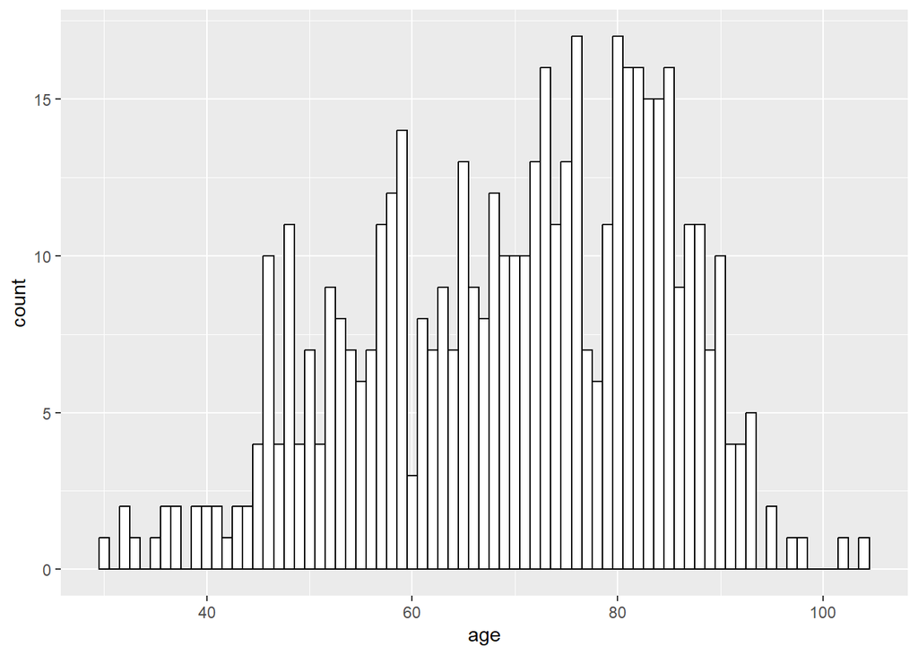

```r
whas1 |>
  ggplot() +
  aes(x=age) |>
  geom_histogram(
    color="black",
    fill="white",
    binwidth=1) -> whas_age_histogram_plot

whas_age_histogram_plot
```

## Create age_groups

```r
whas1 |>
  mutate(age_group=case_when(
    age < 50 ~ "50 years and under",
    age < 60 ~ "60 to 69 years",
    age < 70 ~ "70 to 79 years",
    age >= 80 ~ "80 years and above")) -> whas2
```

## Draw Kaplan-Meier curves for age groups

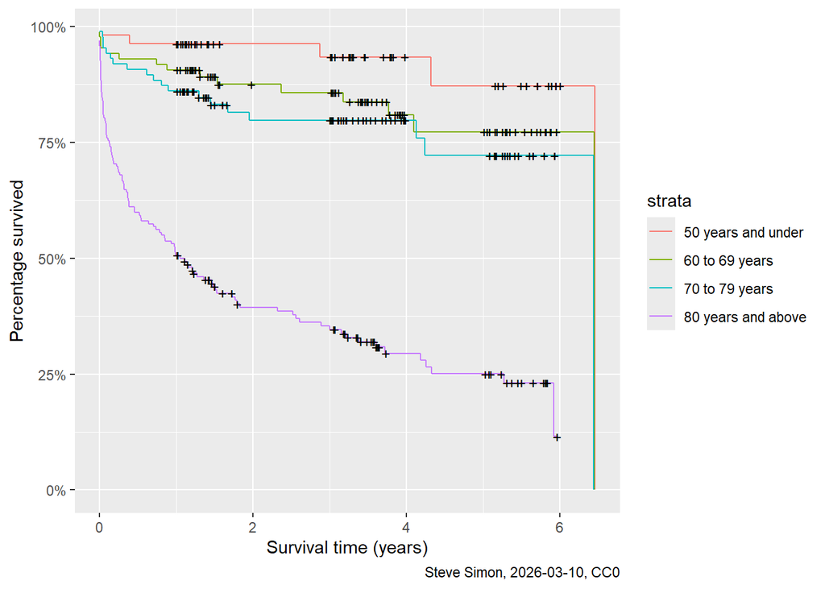

```r
whas_age_group_km_model <- survfit(
  formula=Surv(lenfol, fstat) ~ age_group,
  data=whas2)

autoplot(whas_age_group_km_model, conf.int=FALSE) +
  labs(
    x="Survival time (years)",
    y="Percentage survived",
    caption="Steve Simon, 2026-03-10, CC0") -> whas_age_km_plot

whas_age_km_plot
```

#### Comments on the code

You cannot do a good visualization of Kaplan-Meier curves for age. Age is continuous and there are too many values. You can get a rough approximation of the trends with age by creating age groups and seeing if they follow a dose-response pattern.

#### Interpretation of the output

Here the groups are ordered as you would expect, with the youngest patients closest to the happy upper right corner and the oldest patients closest to the sad lower left corner.

## Cox model for age

```r
whas1 |>
  mutate(age_in_decades=age/10) -> whas2

coxph(
  formula=Surv(lenfol, fstat) ~ age_in_decades,
  data=whas2) -> whas_age_cox_model

whas_age_cox_model
```

```
Call:
coxph(formula = Surv(lenfol, fstat) ~ age_in_decades, data = whas2)

                  coef exp(coef) se(coef)     z      p
age_in_decades 0.66339   1.94136  0.06079 10.91 <2e-16

Likelihood ratio test=142.1  on 1 df, p=< 2.2e-16
n= 500, number of events= 215
```

#### Comments on the code

Many times in these survival models, you get more interesting and interpretable results by changing the units of measure. In this example, I convert age in years to age in decades. A one unit change for the latter variable means a change in risk for a one unit (one decade) change in age.

#### Interpretation of the output

Each additional decade causes an almost doubling of the hazard function.

## Comparison of ages by gender

```r
whas2 |>
    group_by(gender) |>
    summarize(age_mean=mean(age)) -> whas_imbalance_mean_table

whas_imbalance_mean_table
```

```
# A tibble: 2 × 2
  gender age_mean
   <dbl>    <dbl>
1      0     66.6
2      1     74.7
```

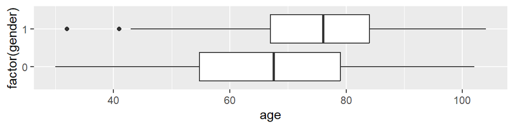

```r
whas2 |>
  ggplot() +
  aes(x=age, y=factor(gender)) +
  geom_boxplot() -> whas_imbalance_box_plot

whas_imbalance_box_plot
```

#### Comments on the code

Perhaps an imbalance in ages between males and females could account for the worse survival results among females. Let’s look at some descriptive statistics and a boxplot to see.

#### Interpretation of the output

Both the means and the boxplot indicate that males (gender=0) tend to be younger than females.

## Test for gender, adjusting for age

```r
coxph(
  formula=Surv(lenfol, fstat) ~ gender + age_in_decades,
  data=whas2) -> whas_adjusted_cox_model

whas_adjusted_cox_model
```

```
Call:
coxph(formula = Surv(lenfol, fstat) ~ gender + age_in_decades,
    data = whas2)

                   coef exp(coef) se(coef)      z      p
gender         -0.06629   0.93586  0.14058 -0.471  0.637
age_in_decades  0.66928   1.95283  0.06196 10.802 <2e-16

Likelihood ratio test=142.4  on 2 df, p=< 2.2e-16
n= 500, number of events= 215
```

#### Interpretation of the output

Although the unadjusted model showed a strong effect of gender, when you control for the age gap, the hazard ratio for gender becomes statistically non-significant. This indicates, perhaps, that the better survival probabilities for men can be accounted for by the earlier age that they entered into the study.

## Save everything

```r
save.image(file="../data/module08.RData")
```